# Spatial Activities and Other Spatial Measures

Mikah Nelson

2023-10-10

## Script Rundown

### Purpose

Determine how experience in everyday activities affects spatial ability, activity experience, looking closely at video game experience. Small scale spatial tasks include the Mental Rotation Task - Shepard and Metzler (MRT), Paper Folding, and Object Assembly. We also look at Perspective Tasking tasks, such as the Spatial Orientation Task (SOT) and Road Map. Lastly we look at large scale tasks such as immersive Virtual Reality paradigms such as Dual Solutions Paradigm (DSP) using absolute pointing error and wayfinding efficiency, and a Maze task; a desktop task called Virtual SILCton measured in absolute pointing error within and between routes calculated in z-scores, and a desktop Route Learning task. Questionaires measuring everyday experience and general intelligence included here are the SoCal Spatial Activities Questionaire (SoCalSAQ), a video game experience questionnaire, and Raven’s Progressive Matrices (RPM).

### Packages

```r
#clean environment
rm(list = ls())

#load packages
library(pacman)
p_load(dplyr, tidyverse, apaTables, ggplot2, correlation)
```

### Descriptive Statistics

```r
#Setting wd
setwd("/Users/mikah/Desktop/Rstudiodata/")
df <- read.csv("spatial activities paper data - activities.csv")

#Overall summary
summary(df)
```

```
##       PID           absDsp        inefficiency   absWithinSilcton
##  Min.   :1001   Min.   : 12.00   Min.   :1.050   Min.   :-1.1040
##  1st Qu.:1048   1st Qu.: 69.02   1st Qu.:1.570   1st Qu.:-0.8410
##  Median :2005   Median : 80.61   Median :1.950   Median :-0.2590
##  Mean   :1571   Mean   : 75.30   Mean   :1.925   Mean   :-0.1048
##  3rd Qu.:2060   3rd Qu.: 88.61   3rd Qu.:2.190   3rd Qu.: 0.3080
##  Max.   :2984   Max.   :106.08   Max.   :4.620   Max.   : 2.1010
##                 NA's   :14       NA's   :16      NA's   :101
##  absBetweenSilcton  mrtCorrectZScore     mrtRTZScore          paperFold
##  Min.   :-1.81800   Min.   :-2.838838   Min.   :-1.470219   Min.   : 1.75
##  1st Qu.:-0.70450   1st Qu.:-0.606044   1st Qu.:-0.677471   1st Qu.:11.00
##  Median : 0.04600   Median : 0.287073   Median :-0.224730   Median :12.75
##  Mean   :-0.04255   Mean   :-0.002676   Mean   : 0.003214   Mean   :12.83
##  3rd Qu.: 0.82000   3rd Qu.: 0.733632   3rd Qu.: 0.491921   3rd Qu.:15.38
##  Max.   : 2.15400   Max.   : 1.291831   Max.   : 5.320459   Max.   :20.00
##  NA's   :101        NA's   :6           NA's   :6           NA's   :94
##     roadMap          ravens        routeError          sot
##  Min.   : 1.00   Min.   : 4.00   Min.   : 0.000   Min.   : 1.270
##  1st Qu.: 7.00   1st Qu.:10.00   1st Qu.: 1.000   1st Qu.: 9.525
##  Median :10.00   Median :12.00   Median : 5.000   Median :18.415
##  Mean   :11.48   Mean   :11.88   Mean   : 7.124   Mean   :22.379
##  3rd Qu.:15.00   3rd Qu.:14.00   3rd Qu.: 8.000   3rd Qu.:31.565
##  Max.   :42.00   Max.   :18.00   Max.   :53.000   Max.   :88.640
##  NA's   :5       NA's   :37      NA's   :92       NA's   :25
##  objectAssemble     mazeAbs       mazeGraphPercent   mazeIneff
##  Min.   : 7.00   Min.   : 13.45   Min.   :0.0000   Min.   :0.110
##  1st Qu.:14.00   1st Qu.: 33.13   1st Qu.:0.5000   1st Qu.:1.030
##  Median :15.00   Median : 57.56   Median :0.8600   Median :1.110
##  Mean   :14.65   Mean   : 56.26   Mean   :0.7526   Mean   :1.138
##  3rd Qu.:16.00   3rd Qu.: 76.83   3rd Qu.:0.9600   3rd Qu.:1.220
##  Max.   :16.00   Max.   :122.67   Max.   :2.1500   Max.   :1.980
##  NA's   :92      NA's   :51       NA's   :26       NA's   :27
##       nav             game          creative        fitness
##  Min.   :1.000   Min.   :1.000   Min.   :1.000   Min.   :1.000
##  1st Qu.:1.690   1st Qu.:1.640   1st Qu.:1.400   1st Qu.:1.800
##  Median :2.000   Median :2.270   Median :1.800   Median :2.400
##  Mean   :2.204   Mean   :2.361   Mean   :2.079   Mean   :2.464
##  3rd Qu.:2.690   3rd Qu.:3.180   3rd Qu.:2.600   3rd Qu.:2.900
##  Max.   :4.688   Max.   :5.500   Max.   :5.400   Max.   :5.000
##  NA's   :21      NA's   :21      NA's   :21      NA's   :21
##    technical     video.game.experience
##  Min.   :1.000   Min.   :0.250
##  1st Qu.:1.170   1st Qu.:2.550
##  Median :1.670   Median :3.500
##  Mean   :1.909   Mean   :3.312
##  3rd Qu.:2.330   3rd Qu.:4.235
##  Max.   :5.500   Max.   :5.075
##  NA's   :21      NA's   :18
```

```r
#sd
sd <- apply(df,2,sd, na.rm = T)
#print sd in console
sd
```

```
##                   PID                absDsp          inefficiency
##           517.0578630            20.2132543             0.5177691
##      absWithinSilcton     absBetweenSilcton      mrtCorrectZScore
##             0.8380971             0.9984366             1.0007089
##           mrtRTZScore             paperFold               roadMap
##             0.9987255             3.8001481             6.2041225
##                ravens            routeError                   sot
##             2.7238818             9.0651935            17.3920774
##        objectAssemble               mazeAbs      mazeGraphPercent
##             1.5381595            25.8778762             0.3159357
##             mazeIneff                   nav                  game
##             0.2159644             0.7379958             0.9089065
##              creative               fitness             technical
##             0.8977531             0.7724826             0.9417151
## video.game.experience
##             1.1451849
```

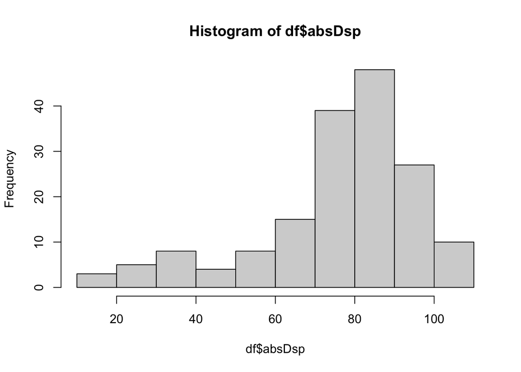

```r
#distribution for DSP VR
hist(df$absDsp)
```

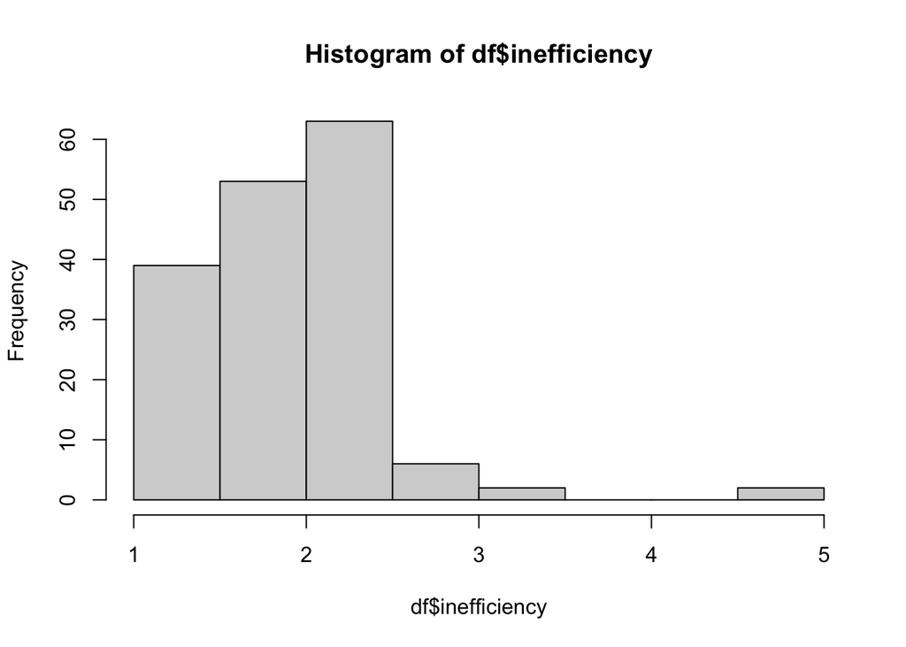

```r
  hist(df$inefficiency)
```

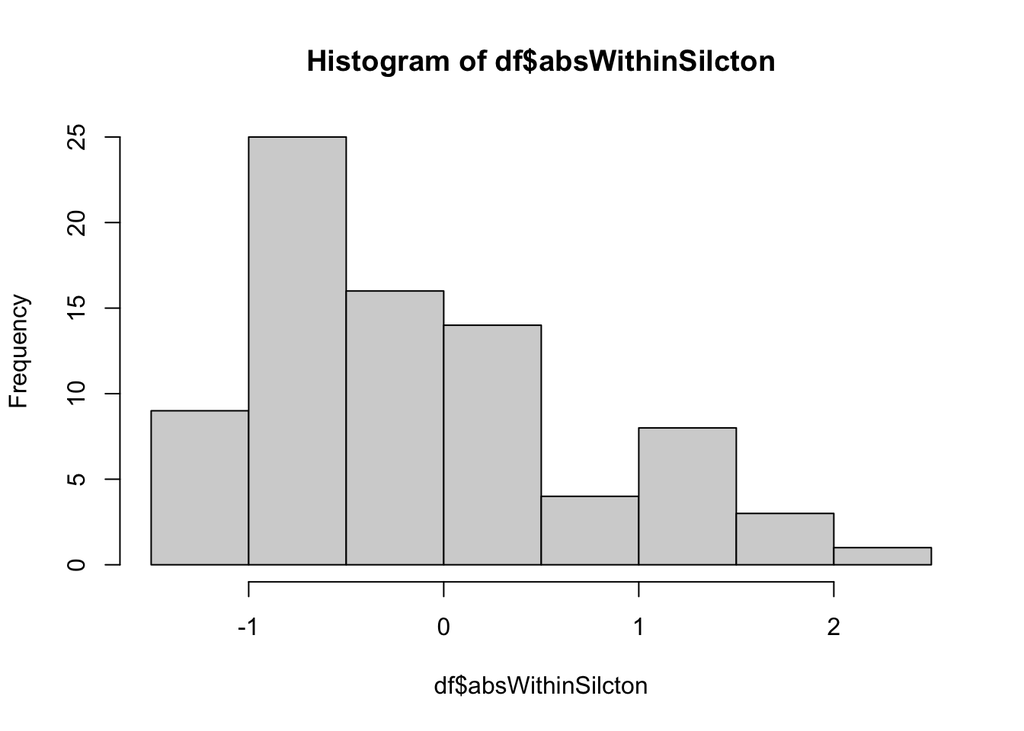

```r
#distribution for SILCton -desktop
hist(df$absWithinSilcton)
```

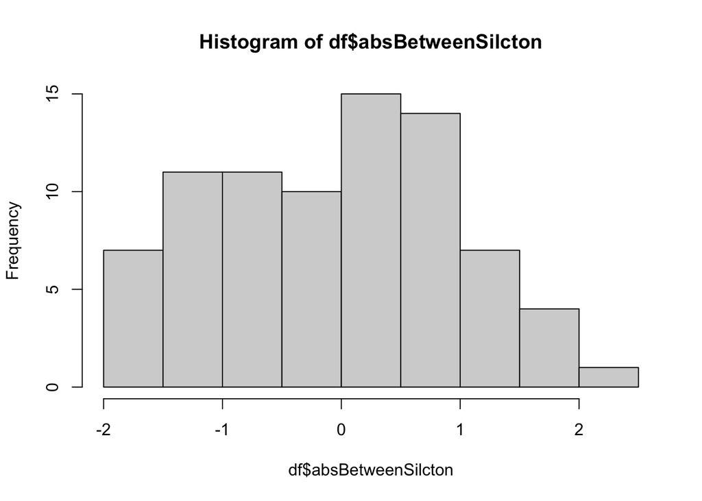

```r
  hist(df$absBetweenSilcton)
```

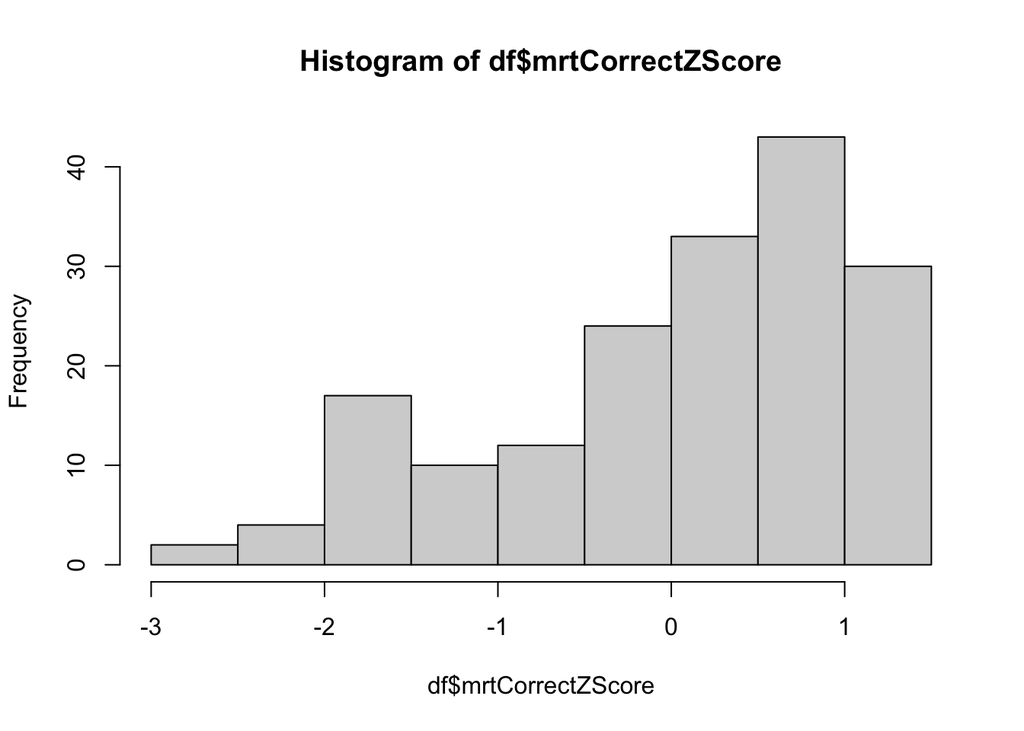

```r
#distribution for MRT
hist(df$mrtCorrectZScore)
```

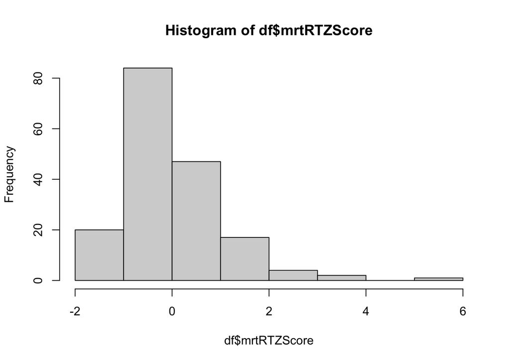

```r
  hist(df$mrtRTZScore)
```

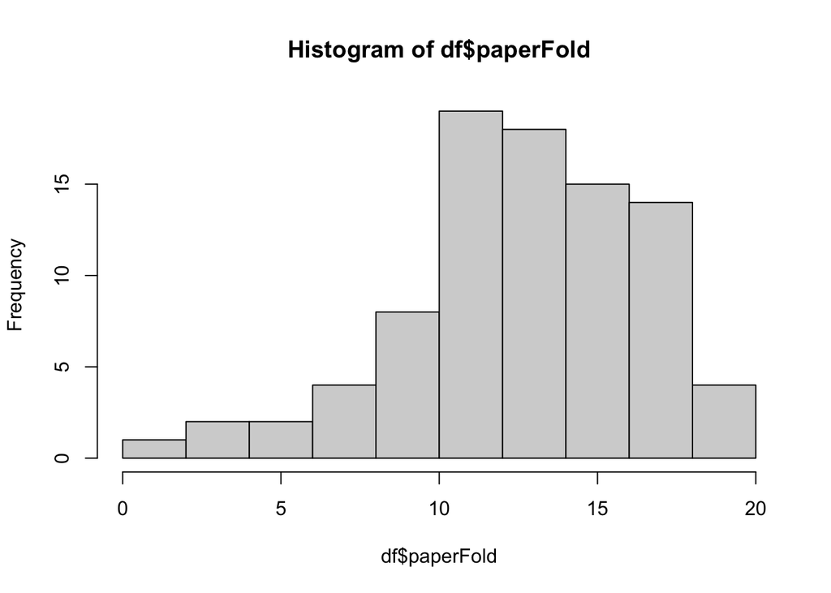

```r
#distribution for paper folding
hist(df$paperFold)
```

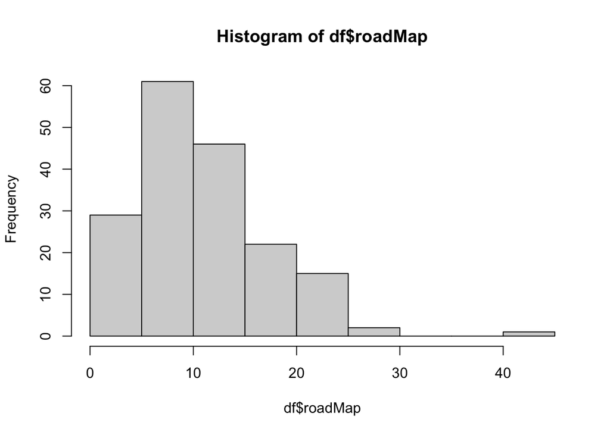

```r
#distribution for RoadMap
hist(df$roadMap)
```

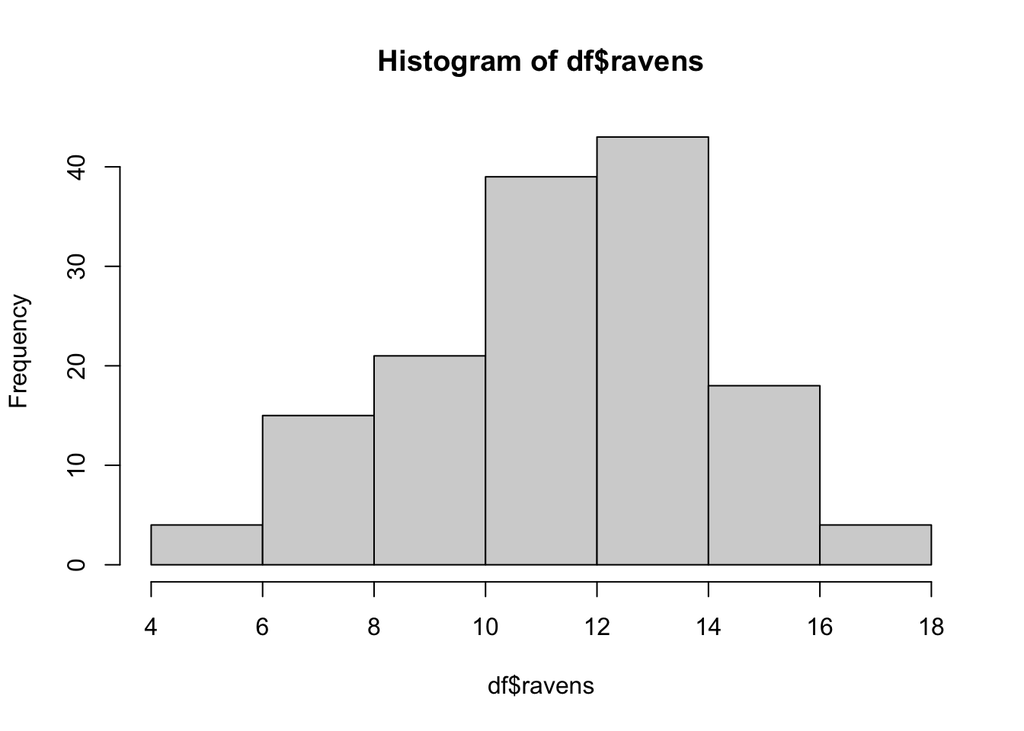

```r
#distribution for
hist(df$ravens)
```

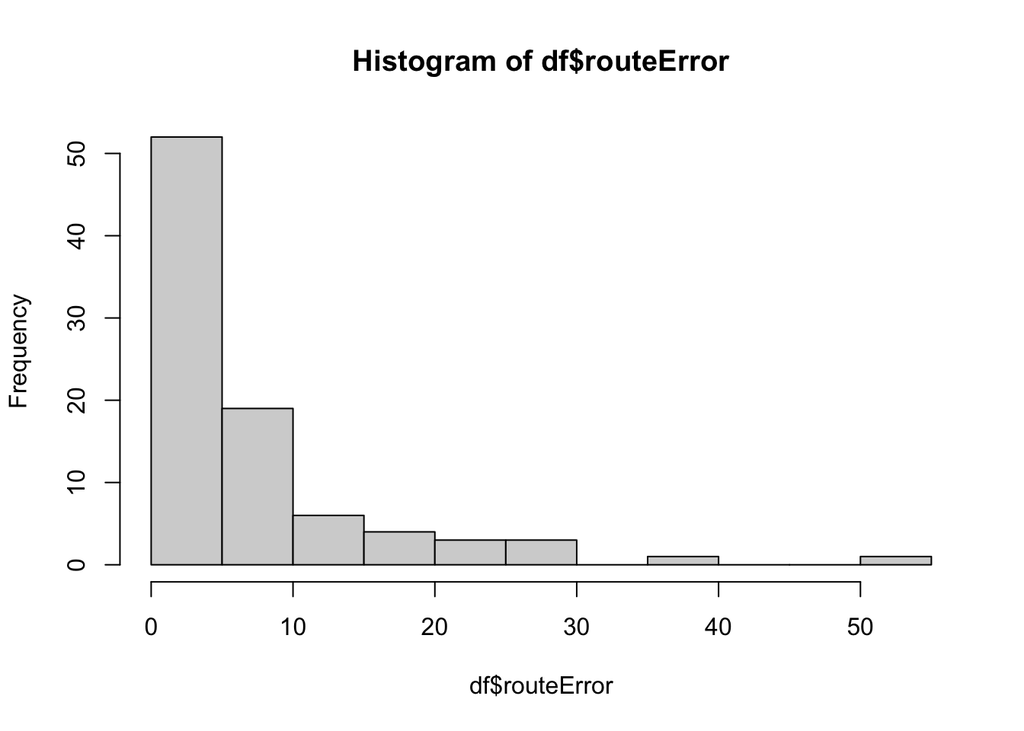

```r
#distribution for route learning - desktop
hist(df$routeError)
```

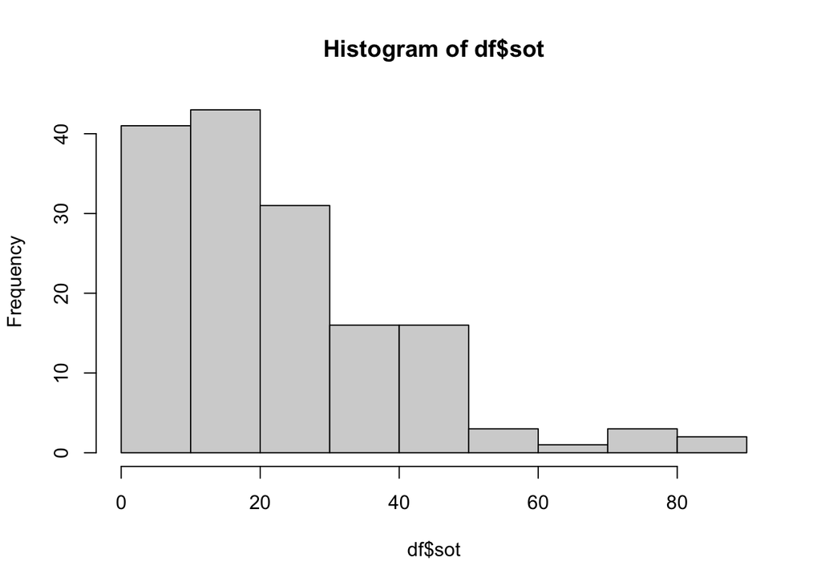

```r
#distribution for SOT
hist(df$sot)
```

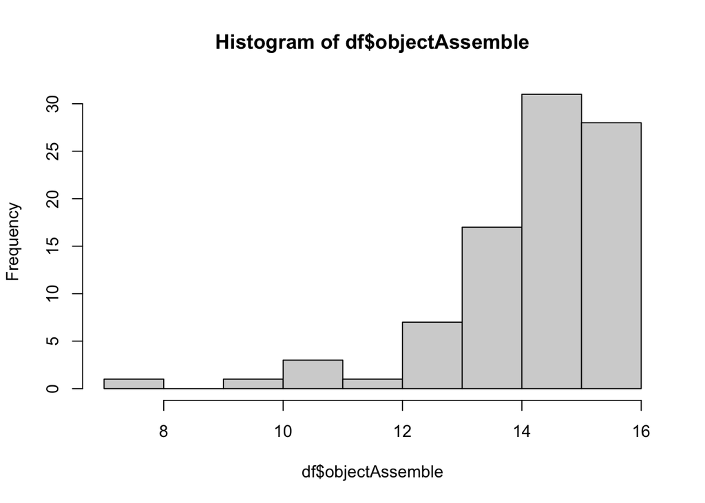

```r
#distribution for object assembly
hist(df$objectAssemble)
```

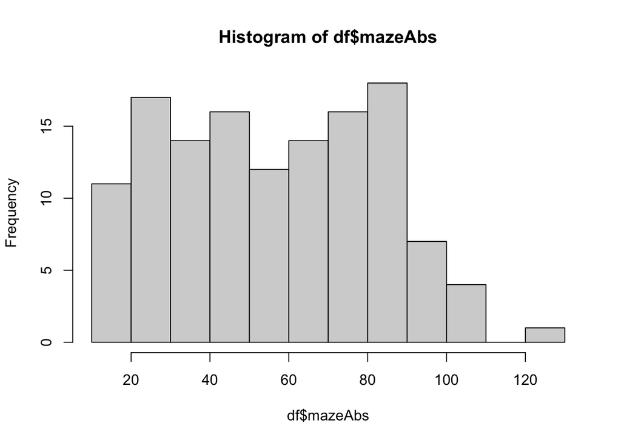

```r
#distribution for Maze task - VR
hist(df$mazeAbs)
```

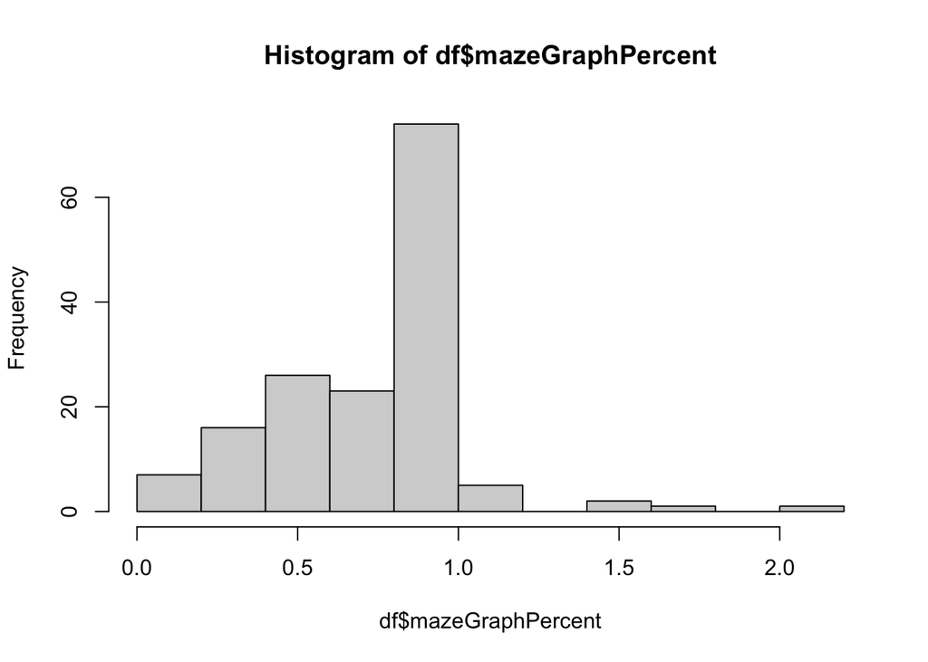

```r
hist(df$mazeGraphPercent)
```

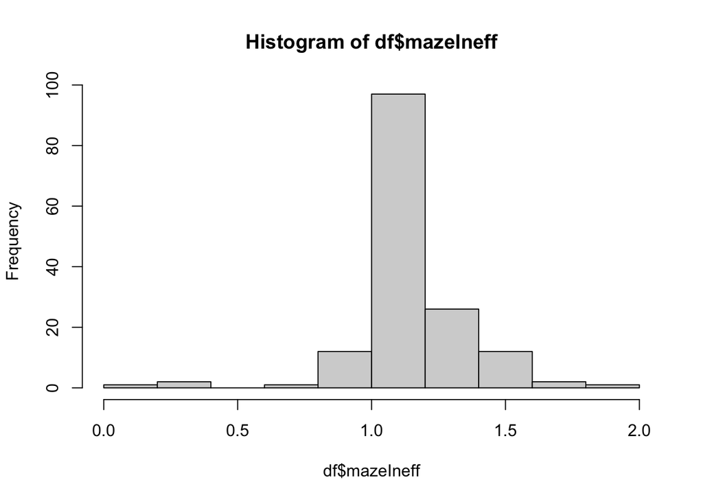

```r
hist(df$mazeIneff)
```

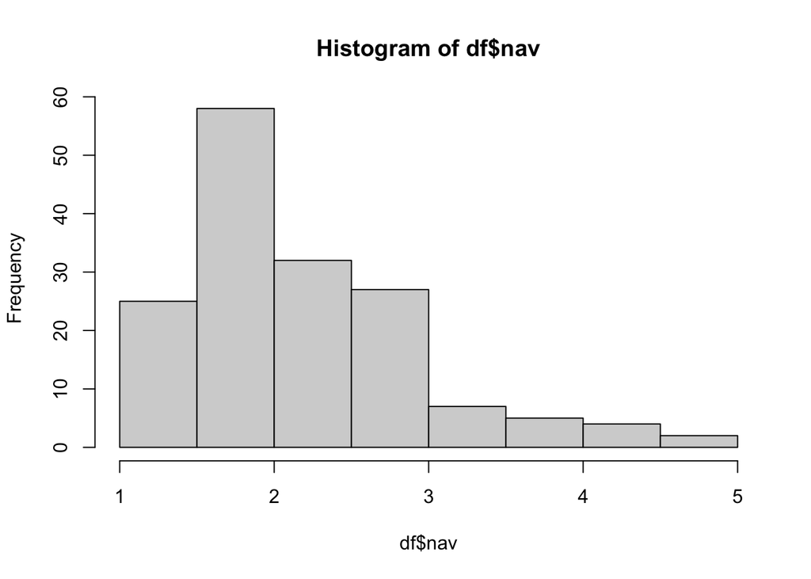

```r
#distribution for SoCalSAQ
hist(df$nav)
```

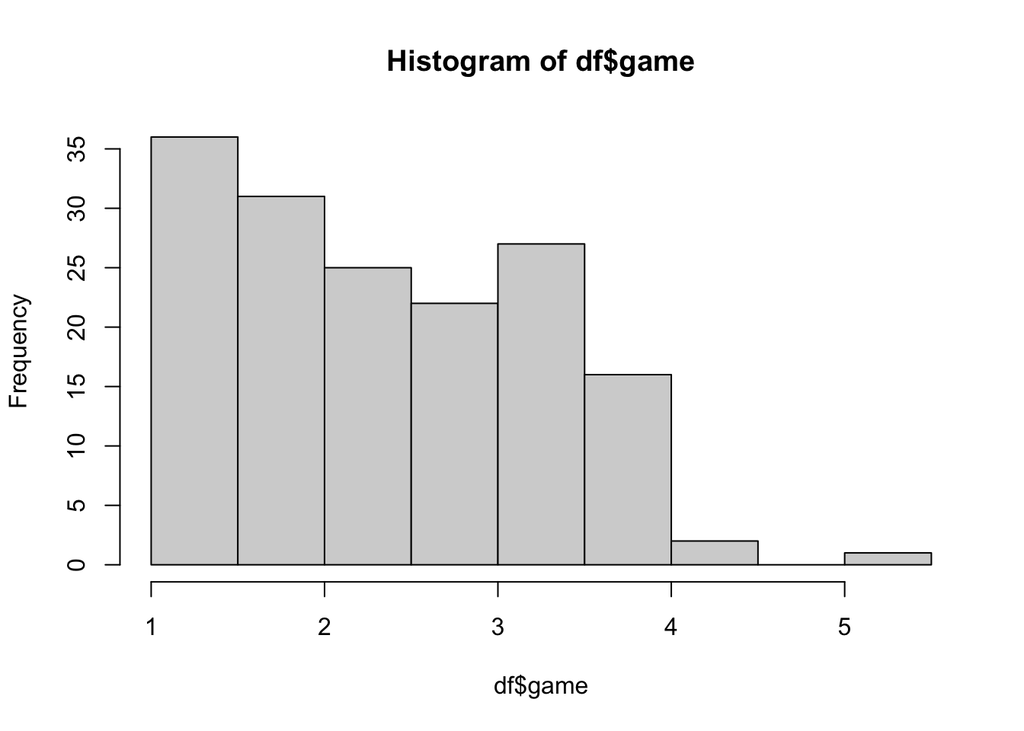

```r
hist(df$game)
```

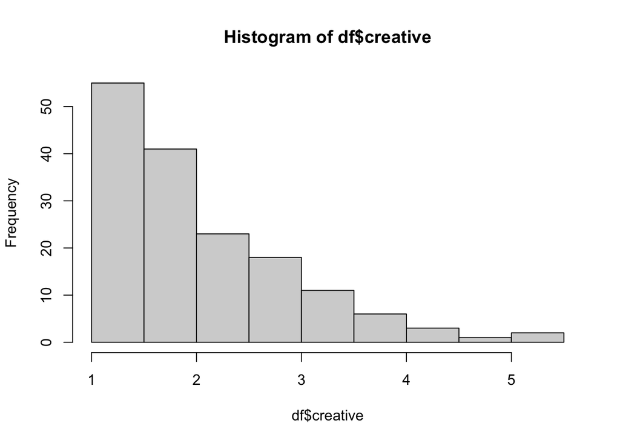

```r
hist(df$creative)
```

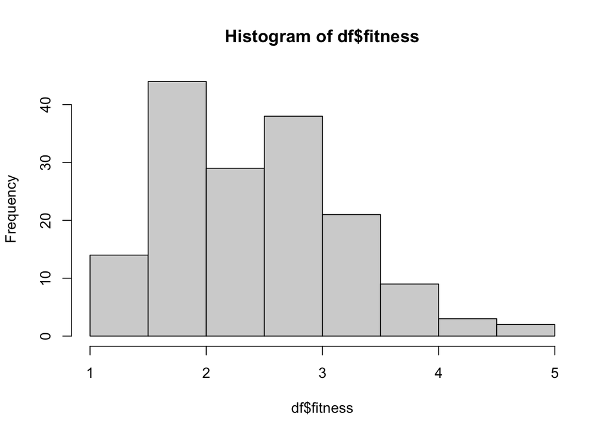

```r
hist(df$fitness)
```

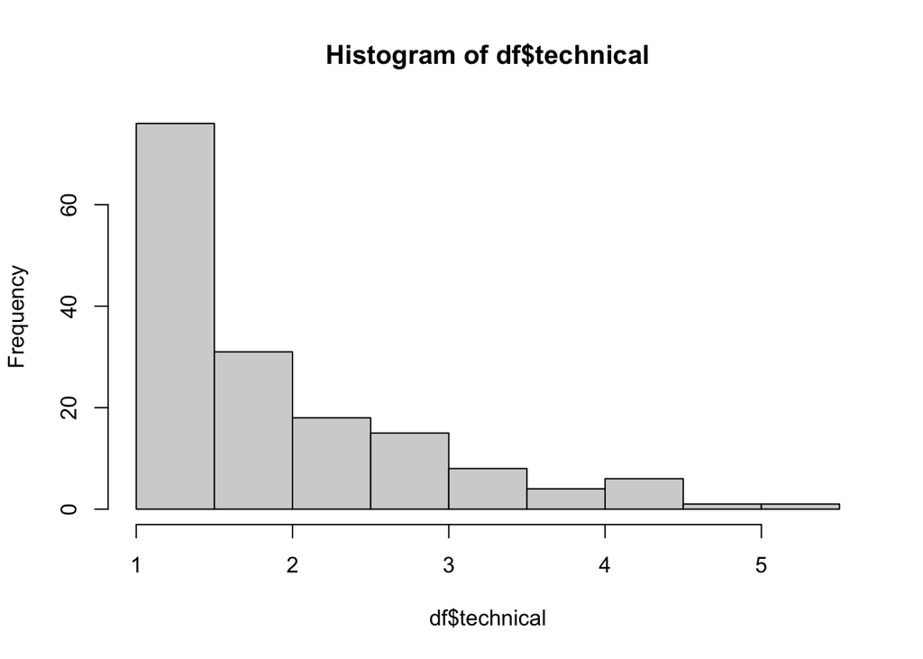

```r
hist(df$technical)
```

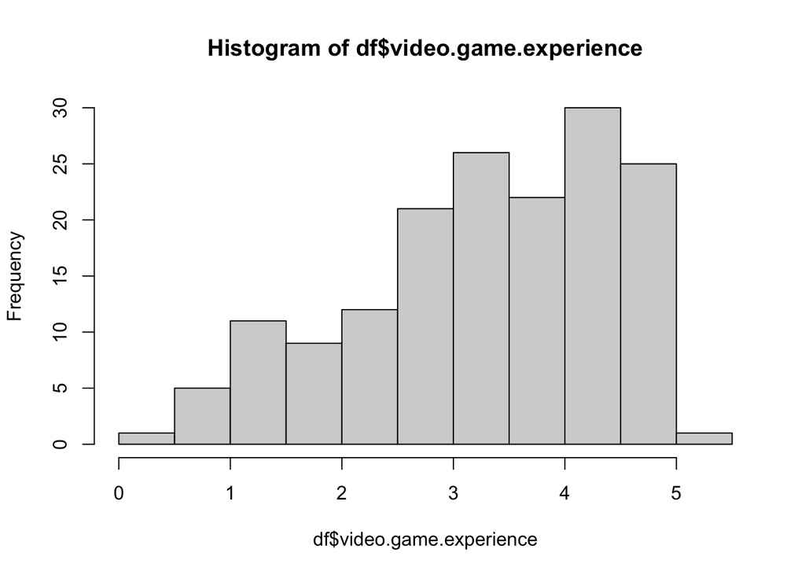

```r
#distribution for VG experience questionnaire
hist(df$video.game.experience)
```

### Correlation

```r
#get correlation for every measure against each other.
results <- correlation(df)

#modify dataframe, analyzed in pearson correlation method
colnames(results)
```

```
##  [1] "Parameter1" "Parameter2" "r"          "CI"         "CI_low"
##  [6] "CI_high"    "t"          "df_error"   "p"          "Method"
## [11] "n_Obs"
```

```r
resultsCorr = subset(results, select = -c(CI, CI_low, CI_high,
                                      t, df_error, Method))
#remove irrelevant lines
results <- results[-(1:21),]
results
```

```
## # Correlation Matrix (pearson-method)
##
## Parameter1        |            Parameter2 |         r |         95% CI |         t |  df |         p
## ----------------------------------------------------------------------------------------------------
## absDsp            |          inefficiency |      0.44 | [ 0.31,  0.56] |      6.24 | 160 | < .001***
## absDsp            |      absWithinSilcton |      0.23 | [ 0.01,  0.43] |      2.10 |  78 | > .999
## absDsp            |     absBetweenSilcton |      0.13 | [-0.09,  0.34] |      1.14 |  78 | > .999
## absDsp            |      mrtCorrectZScore |     -0.35 | [-0.48, -0.21] |     -4.78 | 160 | < .001***
## absDsp            |           mrtRTZScore |     -0.05 | [-0.20,  0.11] |     -0.62 | 160 | > .999
## absDsp            |             paperFold |     -0.24 | [-0.43, -0.03] |     -2.31 |  85 | > .999
## absDsp            |               roadMap |     -0.18 | [-0.32, -0.02] |     -2.27 | 161 | > .999
## absDsp            |                ravens |     -0.26 | [-0.41, -0.10] |     -3.26 | 142 | 0.247
## absDsp            |            routeError |      0.16 | [-0.05,  0.36] |      1.51 |  87 | > .999
## absDsp            |                   sot |      0.22 | [ 0.06,  0.37] |      2.75 | 144 | > .999
## absDsp            |        objectAssemble |     -0.12 | [-0.32,  0.09] |     -1.13 |  87 | > .999
## absDsp            |               mazeAbs |      0.41 | [ 0.26,  0.55] |      5.04 | 125 | < .001***
## absDsp            |      mazeGraphPercent |     -0.25 | [-0.39, -0.10] |     -3.17 | 150 | 0.310
## absDsp            |             mazeIneff |      0.02 | [-0.14,  0.18] |      0.31 | 149 | > .999
## absDsp            |                   nav |     -0.18 | [-0.33, -0.03] |     -2.30 | 155 | > .999
## absDsp            |                  game |     -0.17 | [-0.32, -0.02] |     -2.20 | 155 | > .999
## absDsp            |              creative |     -0.21 | [-0.35, -0.05] |     -2.67 | 155 | > .999
## absDsp            |               fitness |     -0.11 | [-0.26,  0.05] |     -1.37 | 155 | > .999
## absDsp            |             technical |     -0.13 | [-0.28,  0.02] |     -1.67 | 155 | > .999
## absDsp            | video.game.experience |     -0.08 | [-0.23,  0.07] |     -1.04 | 158 | > .999
## inefficiency      |      absWithinSilcton |      0.21 | [-0.02,  0.41] |      1.85 |  77 | > .999
## inefficiency      |     absBetweenSilcton |      0.07 | [-0.15,  0.29] |      0.64 |  77 | > .999
## inefficiency      |      mrtCorrectZScore |     -0.20 | [-0.34, -0.04] |     -2.53 | 158 | > .999
## inefficiency      |           mrtRTZScore |      0.03 | [-0.12,  0.19] |      0.43 | 158 | > .999
## inefficiency      |             paperFold |     -0.14 | [-0.34,  0.07] |     -1.33 |  84 | > .999
## inefficiency      |               roadMap |     -0.13 | [-0.27,  0.03] |     -1.59 | 159 | > .999
## inefficiency      |                ravens |     -0.19 | [-0.34, -0.02] |     -2.23 | 137 | > .999
## inefficiency      |            routeError |      0.27 | [ 0.06,  0.45] |      2.60 |  87 | > .999
## inefficiency      |                   sot |      0.19 | [ 0.03,  0.35] |      2.37 | 142 | > .999
## inefficiency      |        objectAssemble | -1.95e-03 | [-0.21,  0.21] |     -0.02 |  86 | > .999
## inefficiency      |               mazeAbs |      0.40 | [ 0.24,  0.54] |      4.89 | 126 | < .001***
## inefficiency      |      mazeGraphPercent |     -0.24 | [-0.38, -0.08] |     -3.00 | 150 | 0.514
## inefficiency      |             mazeIneff |      0.19 | [ 0.03,  0.34] |      2.31 | 149 | > .999
## inefficiency      |                   nav |     -0.08 | [-0.24,  0.08] |     -1.01 | 153 | > .999
## inefficiency      |                  game |     -0.15 | [-0.30,  0.01] |     -1.87 | 153 | > .999
## inefficiency      |              creative |      0.02 | [-0.13,  0.18] |      0.31 | 153 | > .999
```

[output cut: 162 more lines]

```
## nav               |             technical |      0.40 | [ 0.26,  0.52] |      5.49 | 158 | < .001***
## nav               | video.game.experience |      0.15 | [ 0.00,  0.30] |      1.95 | 156 | > .999
## game              |              creative |      0.21 | [ 0.06,  0.35] |      2.70 | 158 | > .999
## game              |               fitness |      0.33 | [ 0.19,  0.47] |      4.46 | 158 | 0.003**
## game              |             technical |      0.35 | [ 0.20,  0.48] |      4.67 | 158 | 0.001**
## game              | video.game.experience |      0.70 | [ 0.61,  0.77] |     12.12 | 156 | < .001***
## creative          |               fitness |      0.52 | [ 0.39,  0.62] |      7.61 | 158 | < .001***
## creative          |             technical |      0.37 | [ 0.23,  0.50] |      4.99 | 158 | < .001***
## creative          | video.game.experience |      0.07 | [-0.08,  0.23] |      0.90 | 156 | > .999
## fitness           |             technical |      0.34 | [ 0.20,  0.47] |      4.56 | 158 | 0.002**
## fitness           | video.game.experience |      0.12 | [-0.04,  0.27] |      1.52 | 156 | > .999
## technical         | video.game.experience |      0.12 | [-0.03,  0.27] |      1.55 | 156 | > .999
##
## p-value adjustment method: Holm (1979)
## Observations: 46-175
```

#### Standardization

```r
#create a standardized data frame for scores
standardDf <- data.frame(scale(df,center = TRUE, scale = TRUE))

#omit the incomplete data cases, only completely filled rows will be analyzed (optional step)
standardDf <- na.omit(standardDf)
standardDf
```

```
##            PID      absDsp inefficiency absWithinSilcton absBetweenSilcton
## 2   -1.1005960 -0.54324348  -0.89872758      -1.18985311       -1.46874618
## 3   -1.0986620  0.00590115  -0.06824149       2.07468491       -0.12164017
## 4   -1.0967280  0.05537364  -0.35794594      -1.13854641       -1.62398888
## 5   -1.0947940 -0.82177359  -0.93735484      -0.24724162        0.57544964
## 6   -1.0928599  0.46995310   0.06695392      -0.10406013       -0.50724300
## 7   -1.0909259  0.48133177   0.47254015       2.63189955        1.55498100
## 9   -1.0870579 -0.01388785   0.22146296       0.64167681       -0.25885468
## 10  -1.0851239  0.82467084   1.12920357      -1.16240999       -1.20633594
## 12  -1.0812558 -0.27361841   0.20214933      -0.60638853       -0.01847889
## 13  -1.0793218  0.23100097  -0.18412327       0.95428973       -0.19675760
## 14  -1.0754538 -0.08908603  -0.14549601      -0.20428718        0.84887710
## 15  -1.0715857  0.79894515  -0.47382772      -1.04189891       -0.58536514
## 16  -1.0696517  0.46451112   0.53048104       1.78474238        0.94602899
## 17  -1.0677177  0.78212450   0.26009022      -1.07530792       -0.39907390
```

[output cut: 180 more lines]

### Create Linear Model

Can run this script with either all NA’s or na.omit [ted], which will analyze only completely filled in rows. In this version and its corresponding results, na.omit is set to run.

### Navigation Model

The navigation component of SoCalSAQ is best modeled when the predictor are large scale tasks, but is only correlated significantly with the RoadMap component in the correlation matrix. With na.omit, small scale tasks are the best fitting model, but not significantly differently than the other models.

```r
#create linear models
#navigation and the only sig. corrr -- perspective taking
perspectNavModel <- lm(nav ~ sot+roadMap, data = standardDf)
perspectNavModelSum <- summary(perspectNavModel)
msePerspectNav <- mean(perspectNavModelSum$residuals^2)
msePerspectNav
```

```
## [1] 0.4317049
```

```r
largeNavModel <- lm(nav ~ absDsp+inefficiency+absWithinSilcton+ absBetweenSilcton+routeError+mazeAbs+mazeGraphPercent+mazeIneff, data=standardDf)
largeNavModelSum <- summary(largeNavModel)
mseLargeNav <- mean(largeNavModelSum$residuals^2)
#best predictor
mseLargeNav
```

```
## [1] 0.3599779
```

```r
smallNavModel <- lm(nav ~ mrtCorrectZScore+mrtRTZScore+paperFold+objectAssemble, data=standardDf)
smallNavModelSum <- summary(smallNavModel)
mseSmallNav <- mean(smallNavModelSum$residuals^2)
mseSmallNav
```

```
## [1] 0.3402802
```

```r
var.test(largeNavModelSum$residuals, smallNavModelSum$residuals,
         alternative = "less")
```

```
##
##  F test to compare two variances
##
## data:  largeNavModelSum$residuals and smallNavModelSum$residuals
## F = 1.0579, num df = 37, denom df = 37, p-value = 0.5675
## alternative hypothesis: true ratio of variances is less than 1
## 95 percent confidence interval:
##  0.000000 1.829623
## sample estimates:
## ratio of variances
##           1.057887
```

```r
#p-value = 0.01165
#large is a significantly better predictor than small

var.test(largeNavModelSum$residuals, perspectNavModelSum$residuals,
         alternative = "less")
```

```
##
##  F test to compare two variances
##
## data:  largeNavModelSum$residuals and perspectNavModelSum$residuals
## F = 0.83385, num df = 37, denom df = 37, p-value = 0.2917
## alternative hypothesis: true ratio of variances is less than 1
## 95 percent confidence interval:
##  0.000000 1.442152
## sample estimates:
## ratio of variances
##          0.8338517
```

```r
# p-value = 0.003053
#large scale activities for nav is a 'better' sig. predictor than perspective

var.test(smallNavModelSum$residuals, perspectNavModelSum$residuals,
         alternative = "less")
```

```
##
##  F test to compare two variances
##
## data:  smallNavModelSum$residuals and perspectNavModelSum$residuals
## F = 0.78822, num df = 37, denom df = 37, p-value = 0.2364
## alternative hypothesis: true ratio of variances is less than 1
## 95 percent confidence interval:
##  0.000000 1.363239
## sample estimates:
## ratio of variances
##          0.7882239
```

```r
#p-value = 0.3084
```

### Game Model

The game and competition component of SoCalSAQ is best modeled when the predictors are large scale tasks, but is only significantly different from the gaming + perspective taking model; the small scale predictors are not significantly different. None are sig. if na.omit is included.

```r
#large scale tasks and game Socal SAQ
largeGameModel <- lm(game ~ absDsp+inefficiency+absWithinSilcton+ absBetweenSilcton+routeError+mazeAbs+mazeGraphPercent+mazeIneff, data=standardDf)
largeGameModelSum <- summary(largeGameModel)
#get mean squared error to test if they are different
mseLargeGame <- mean(largeGameModelSum$residuals^2)
mseLargeGame
```

```
## [1] 0.4702029
```

```r
#0.4549973

#small game model
smallGameModel <- lm(game ~ mrtCorrectZScore+mrtRTZScore+paperFold+objectAssemble, data=standardDf)
smallGameModelSum <- summary(smallGameModel)
mseSmallGame <- mean(smallGameModelSum$residuals^2)
mseSmallGame
```

```
## [1] 0.6142951
```

```r
# 0.6628367

#game perspective model
perspectGameModel <- lm(game ~ sot+roadMap, data = standardDf)
perspectGameModelSum <- summary(perspectGameModel)
msePerspectGame <- mean(perspectGameModelSum$residuals^2)
msePerspectGame
```

```
## [1] 0.5421357
```

```r
#0.7776601

#Running an F-Test#

var.test(largeGameModelSum$residuals, smallGameModelSum$residuals,
         alternative = "less")
```

```
##
##  F test to compare two variances
##
## data:  largeGameModelSum$residuals and smallGameModelSum$residuals
## F = 0.76543, num df = 37, denom df = 37, p-value = 0.21
## alternative hypothesis: true ratio of variances is less than 1
## 95 percent confidence interval:
##  0.000000 1.323825
## sample estimates:
## ratio of variances
##          0.7654349
```

```r
#p-value = 0.09753

var.test(largeGameModelSum$residuals, perspectGameModelSum$residuals,
         alternative = "less")
```

```
##
##  F test to compare two variances
##
## data:  largeGameModelSum$residuals and perspectGameModelSum$residuals
## F = 0.86732, num df = 37, denom df = 37, p-value = 0.3337
## alternative hypothesis: true ratio of variances is less than 1
## 95 percent confidence interval:
##  0.000000 1.500029
## sample estimates:
## ratio of variances
##          0.8673159
```

```r
# p-value = 0.02641
#large scale activities for gaming is a 'better' sig. predictor than perspective taking tasks.

var.test(smallGameModelSum$residuals, perspectGameModelSum$residuals,
         alternative = "less")
```

```
##
##  F test to compare two variances
##
## data:  smallGameModelSum$residuals and perspectGameModelSum$residuals
## F = 1.1331, num df = 37, denom df = 37, p-value = 0.647
## alternative hypothesis: true ratio of variances is less than 1
## 95 percent confidence interval:
##  0.000000 1.959708
## sample estimates:
## ratio of variances
##           1.133102
```

```r
# p-value = 0.2231
```

### Video Game Experience Model

The video game experience component is best modeled when the predictors are large scale tasks, but is only significantly different from the gaming + perspective taking model; the small scale predictors are not significantly different. With na.omit, perspective taking tasks are the best fit with no sig. differences.

```r
#run models for vg experience
largeVGEModel <- lm(video.game.experience ~ absDsp+inefficiency+absWithinSilcton+ absBetweenSilcton+routeError+mazeAbs+mazeGraphPercent+mazeIneff, data=standardDf)
largeVGEModelSum <- summary(largeVGEModel)
mseLargeVGE <- mean(largeVGEModelSum$residuals^2)
mseLargeVGE
```

```
## [1] 0.7638386
```

```r
#slightly better predictor but not significantly different to run an f-test

smallVGEModel <- lm(video.game.experience~ mrtCorrectZScore+mrtRTZScore+paperFold+objectAssemble, data=standardDf)
smallVGEModelSum <- summary(smallVGEModel)
mseSmallVGE <- mean(smallVGEModelSum$residuals^2)
mseSmallVGE
```

```
## [1] 0.7452967
```

```r
#video game experience + perspective taking tasks
perspectVGEModel <- lm(game ~ sot+roadMap, data = standardDf)
perspectVGEModelSum <- summary(perspectVGEModel)
msePerspectVGE <- mean(perspectVGEModelSum$residuals^2)
msePerspectVGE
```

```
## [1] 0.5421357
```

```r
#[1] 0.7776601

#ran tests but not necessary, nothing sig.
var.test(largeVGEModelSum$residuals, smallVGEModelSum$residuals,
         alternative = "less")
```

```
##
##  F test to compare two variances
##
## data:  largeVGEModelSum$residuals and smallVGEModelSum$residuals
## F = 1.0249, num df = 37, denom df = 37, p-value = 0.5296
## alternative hypothesis: true ratio of variances is less than 1
## 95 percent confidence interval:
##  0.000000 1.772535
## sample estimates:
## ratio of variances
##           1.024879
```

```r
var.test(largeVGEModelSum$residuals, perspectVGEModelSum$residuals,
         alternative = "less")
```

```
##
##  F test to compare two variances
##
## data:  largeVGEModelSum$residuals and perspectVGEModelSum$residuals
## F = 1.4089, num df = 37, denom df = 37, p-value = 0.8492
## alternative hypothesis: true ratio of variances is less than 1
## 95 percent confidence interval:
##  0.000000 2.436778
## sample estimates:
## ratio of variances
##           1.408944
```

```r
var.test(smallVGEModelSum$residuals, perspectVGEModelSum$residuals,
         alternative = "less")
```

```
##
##  F test to compare two variances
##
## data:  smallVGEModelSum$residuals and perspectVGEModelSum$residuals
## F = 1.3747, num df = 37, denom df = 37, p-value = 0.8313
## alternative hypothesis: true ratio of variances is less than 1
## 95 percent confidence interval:
##  0.000000 2.377626
## sample estimates:
## ratio of variances
##           1.374742
```

### Technical Model

```r
#run model for technical component
largeTechModel <- lm(technical ~ absDsp+inefficiency+absWithinSilcton+ absBetweenSilcton+routeError+mazeAbs+mazeGraphPercent+mazeIneff, data=standardDf)
largeTechModelSum <- summary(largeTechModel)
mseLargeTech <- mean(largeTechModelSum$residuals^2)
mseLargeTech
```

```
## [1] 0.5901713
```

```r
#slightly better predictor but not significantly different to run an f-test

#video game experience + perspective taking tasks
perspectTechModel <- lm(technical ~ sot+roadMap, data = standardDf)
perspectTechModelSum <- summary(perspectTechModel)
msePerspectTech <- mean(perspectTechModelSum$residuals^2)
msePerspectTech
```

```
## [1] 0.7445751
```

```r
smallTechModel <- lm(technical ~ mrtCorrectZScore+mrtRTZScore+paperFold+objectAssemble, data=standardDf)
smallTechModelSum <- summary(smallTechModel)
mseSmallTech <- mean(smallTechModelSum$residuals^2)
mseSmallTech
```

```
## [1] 0.7136456
```

```r
#really high mse
#an insanely horrible predictor??? why are these models awful

var.test(largeTechModelSum$residuals, smallTechModelSum$residuals,
         alternative = "less")
```

```
##
##  F test to compare two variances
##
## data:  largeTechModelSum$residuals and smallTechModelSum$residuals
## F = 0.82698, num df = 37, denom df = 37, p-value = 0.2832
## alternative hypothesis: true ratio of variances is less than 1
## 95 percent confidence interval:
##  0.000000 1.430269
## sample estimates:
## ratio of variances
##           0.826981
```

```r
#p-value = 1.268e-13
#
var.test(largeTechModelSum$residuals, perspectTechModelSum$residuals,
         alternative = "less")
```

```
##
##  F test to compare two variances
##
## data:  largeTechModelSum$residuals and perspectTechModelSum$residuals
## F = 0.79263, num df = 37, denom df = 37, p-value = 0.2416
## alternative hypothesis: true ratio of variances is less than 1
## 95 percent confidence interval:
##  0.000000 1.370856
## sample estimates:
## ratio of variances
##          0.7926283
```

```r
#p-value = 0.01013

var.test(smallTechModelSum$residuals, perspectTechModelSum$residuals,
         alternative = "less")
```

```
##
##  F test to compare two variances
##
## data:  smallTechModelSum$residuals and perspectTechModelSum$residuals
## F = 0.95846, num df = 37, denom df = 37, p-value = 0.449
## alternative hypothesis: true ratio of variances is less than 1
## 95 percent confidence interval:
##  0.000000 1.657663
## sample estimates:
## ratio of variances
##          0.9584601
```

```r
#the same predictors essentially???
```

### Intelligence as Predictor for different models?

```r
#ravens and perspective taking
intellPerspectModel <- lm(ravens ~ sot+roadMap , data = standardDf)
intellPerspectModelSum <- summary(intellPerspectModel)
mseIntellPerspect <- mean(intellPerspectModelSum$residuals^2)
mseIntellPerspect
```

```
## [1] 0.8323788
```

```r
#ravens and large scale tasks
intellLargeModel <-  lm(ravens ~ absDsp+inefficiency+absWithinSilcton+ absBetweenSilcton+routeError+mazeAbs+mazeGraphPercent+mazeIneff, data=standardDf)
intellLargeModelSum <- summary(intellLargeModel)
mseIntellLarge <- mean(intellLargeModelSum$residuals^2)
mseIntellLarge
```

```
## [1] 0.6813093
```

```r
#ravens and small scale tasks
intellSmallModel <- lm(ravens ~ mrtCorrectZScore+mrtRTZScore+paperFold+objectAssemble, data=standardDf)
intellSmallModelSum <- summary(intellSmallModel)
mseIntellSmall <- mean(intellSmallModelSum$residuals^2)
mseIntellSmall
```

```
## [1] 0.7068917
```

```r
#best predictor

#not sig. different from each other...
var.test(intellSmallModelSum$residuals, intellLargeModelSum$residuals,
         alternative = "less")
```

```
##
##  F test to compare two variances
##
## data:  intellSmallModelSum$residuals and intellLargeModelSum$residuals
## F = 1.0375, num df = 37, denom df = 37, p-value = 0.5443
## alternative hypothesis: true ratio of variances is less than 1
## 95 percent confidence interval:
##  0.000000 1.794448
## sample estimates:
## ratio of variances
##           1.037549
```

```r
var.test(intellSmallModelSum$residuals, intellPerspectModelSum$residuals,
         alternative = "less")
```

```
##
##  F test to compare two variances
##
## data:  intellSmallModelSum$residuals and intellPerspectModelSum$residuals
## F = 0.84924, num df = 37, denom df = 37, p-value = 0.3109
## alternative hypothesis: true ratio of variances is less than 1
## 95 percent confidence interval:
##  0.000000 1.468771
## sample estimates:
## ratio of variances
##          0.8492428
```

```r
var.test(intellPerspectModelSum$residuals, intellLargeModelSum$residuals,
         alternative = "less")
```

```
##
##  F test to compare two variances
##
## data:  intellPerspectModelSum$residuals and intellLargeModelSum$residuals
## F = 1.2217, num df = 37, denom df = 37, p-value = 0.7272
## alternative hypothesis: true ratio of variances is less than 1
## 95 percent confidence interval:
##  0.000000 2.112998
## sample estimates:
## ratio of variances
##           1.221734
```

### Creative Component Exploratory Analyses

```r
perspectCreativeModel <- lm(creative ~ sot+roadMap, data = standardDf)
perspectCreativeModelSum <- summary(perspectCreativeModel)
msePerspectCreative <- mean(perspectCreativeModelSum$residuals^2)
msePerspectCreative
```

```
## [1] 0.9106905
```

```r
largeCreativeModel <- lm(creative ~ absDsp+inefficiency+absWithinSilcton+ absBetweenSilcton+routeError+mazeAbs+mazeGraphPercent+mazeIneff, data=standardDf)
largeCreativeModelSum <- summary(largeCreativeModel)
mseLargeCreative <- mean(largeCreativeModelSum$residuals^2)
mseLargeCreative
```

```
## [1] 0.6591122
```

```r
#best predictor - [1] 0.5987959

smallCreativeModel <- lm(creative ~ mrtCorrectZScore+mrtRTZScore+paperFold+objectAssemble, data=standardDf)
smallCreativeModelSum <- summary(smallCreativeModel)
mseSmallCreative <- mean(smallCreativeModelSum$residuals^2)
mseSmallCreative
```

```
## [1] 0.7338257
```

```r
var.test(largeCreativeModelSum$residuals, smallCreativeModelSum$residuals,
         alternative = "less")
```

```
##
##  F test to compare two variances
##
## data:  largeCreativeModelSum$residuals and smallCreativeModelSum$residuals
## F = 0.89819, num df = 37, denom df = 37, p-value = 0.3729
## alternative hypothesis: true ratio of variances is less than 1
## 95 percent confidence interval:
##  0.00000 1.55342
## sample estimates:
## ratio of variances
##          0.8981864
```

```r
#p-value = 0.01165
#large is a significantly better predictor than small

var.test(largeCreativeModelSum$residuals, perspectCreativeModelSum$residuals,
         alternative = "less")
```

```
##
##  F test to compare two variances
##
## data:  largeCreativeModelSum$residuals and perspectCreativeModelSum$residuals
## F = 0.72375, num df = 37, denom df = 37, p-value = 0.1649
## alternative hypothesis: true ratio of variances is less than 1
## 95 percent confidence interval:
##  0.000000 1.251731
## sample estimates:
## ratio of variances
##          0.7237499
```

```r
#p-value = 0.03662

var.test(smallCreativeModelSum$residuals, perspectCreativeModelSum$residuals,
         alternative = "less")
```

```
##
##  F test to compare two variances
##
## data:  smallCreativeModelSum$residuals and perspectCreativeModelSum$residuals
## F = 0.80579, num df = 37, denom df = 37, p-value = 0.2573
## alternative hypothesis: true ratio of variances is less than 1
## 95 percent confidence interval:
##  0.00000 1.39362
## sample estimates:
## ratio of variances
##          0.8057904
```

```r
#p-value = 0.3084
```